# Model based visualization of ancient DNA damage using *aRchaic*

Kushal K Dey

Department of Statistics, University of Chicago

Hussein Al-Asadi

Department of Ecology and Evolution, University of Chicago

## Introduction

**aRchaic** is a R/python software environment that performs model based clustering and visualization of ancient and modern DNA samples from one or more studies. This model can be used to identify distinct patterns of DNA damage and is capable of reflecting relative rates of contamination in contaminated aDNA samples.

Here is a visual representation of **aRchaic** on *moderns*, ancient samples treated with UDG library protocol and ancient samples not treated with UDG library protocol.

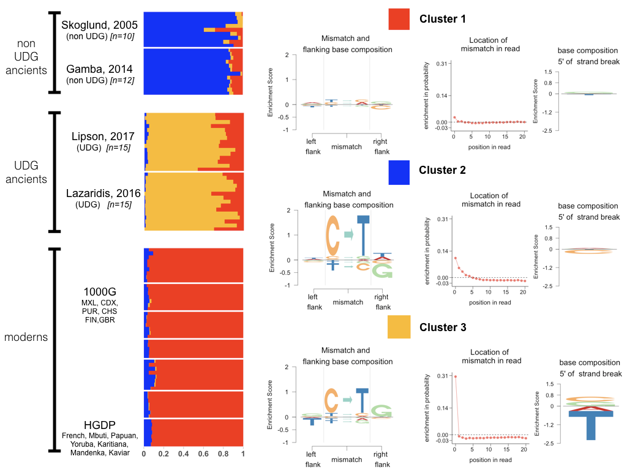

Figure1

## aRchaic workflow

For every mismatch in a BAM file with respect to a reference genome, **aRchaic** records the various features of the mismatch - mismatch type, flanking bases, strand break base, strand and position of mismatch from the ends of read - into a .csv file which we call the *Mismatch Feature Format (MFF)* file.

Next, **aRchaic** fits a mixed membership model on the mismatch feature data that allows each sample to have partial memberships in more than one cluster where the clusters represent distinct mismatch feature profiles.

The cluster memberships from model fit are represented in a stacked bar chart grouped by studies (Figure 1 left), while the clusters are represented as logo plots of enrichment of their mismatch profiles against a modern background (Figure 1 right).

In the next sections, we present a tutorial on how to generate images (like in Figure 1) starting from the BAM files for the samples.

## Installation

First and foremost, the user is required to install [python](https://www.python.org/downloads/) and [R/RStudio](https://www.rstudio.com/) . The version of R must be $>=3.5$. If your R version is lower, please upgrade.

Next, the user needs to install the Python packages [pysam](http://pysam.readthedocs.io/en/latest/installation.html) and [pyfaidx](https://pythonhosted.org/pyfaidx/#installation).

Upon completion of these steps, start a new R session and install the dependency R packages.

```r
install.packages("devtools")
devtools::install_github("kkdey/Logolas")
devtools::install_github("kkdey/CountClust")
devtools::install_github("TaddyLab/maptpx")
```

Next, start a new R session and install the R package **aRchaic**

```r
install.packages("devtools")
devtools::install_github("kkdey/aRchaic")
```

Finally, load aRchaic into R

```r
library(aRchaic)
```

## aRchaic input - MFF file

The **aRchaic** R package requires as input a MismatchFeatureFormat (MFF) file, which is a special type of .csv formatted file. A typical example MFF file looks like the following

```r
mff <- read.csv(system.file("extdata","ancients","NE2_subsampled.csv",package = "aRchaic"), header = FALSE)
head(mff)
```

```
##       V1 V2 V3 V4 V5 V6      V7
## 1 AC->TC 17 48  A  A  - 1557694
## 2 AG->AC 47  9  A  T  + 4607735
## 3 TG->AT 93  1  A  C  - 5166724
## 4 TC->TT 16 50  G  G  - 4581952
## 5 AC->TG 48 31  A  C  +  207160
## 6 GG->AG 33  5  G  G  - 2912042
```

The first column represents mismatch type and flanking bases : (left flank base)(mismatch)(right flank base) <-> (A)(C->T)(C). The second and third columns represent the position of mismatch from 5’ and 3’ ends of reads after mapped to reference. The fourth and 5th columns represent the base 1 base upstream from 5’ end of read and 1 base downstream from 3’ end of read respectively. The 6th column contains information of which strand the read comes from, and the 7th column is an identifier for the read containing the mismatch.

## archaic_prepare()

Suppose you have two folders of MFF files corresponding to two studies - one for moderns and one for ancients. We incorporate them as part of the R package itself - lets call them `moderns` and `ancients`.

- **Modern files** :

```r
moderns_dir <- system.file("extdata","moderns", package = "aRchaic")
list.files(moderns_dir, pattern = ".csv")
```

```
## [1] "NA19788_subsampled.csv" "NA19789_subsampled.csv"
## [3] "NA19792_subsampled.csv" "NA19794_subsampled.csv"
## [5] "NA19795_subsampled.csv"
```

- **Ancient files** :

```r
ancients_dir <- system.file("extdata","ancients", package = "aRchaic")
list.files(ancients_dir, pattern = ".csv")
```

```
## [1] "NE2_subsampled.csv" "NE3_subsampled.csv" "NE4_subsampled.csv"
## [4] "NE5_subsampled.csv" "NE6_subsampled.csv"
```

Each of the folders has 5 MFF files corresponding to 5 samples.

First we prepare the input data to **aRchaic** model from the above data folders.

```r
out <- archaic_prepare(dirs = c(moderns_dir, ancients_dir))
```

The output `out` should be a list with 2 elements - corresponding to 2 study folders. Each element is a matrix with samples along the rows, coded mismatch features along columns, with cells of the matrix recording counts of the number of times a coded mismatch pattern occurs in a sample.

`archaic_prepare` also saves these elements as separate .RData files in each study folder, so they can be re-used for similar analysis downstream more easily without needing to process the MFF files everytime. In fact, if you run

```r
out2 <- archaic_prepare(dirs = c(moderns_dir, ancients_dir))
out3 <- archaic_prepare(dirs = moderns_dir)
```

you will see that `out2` or `out3` no longer process the .csv files in the folders and directly read from the .Rdata file.

We provide [here](https://github.com/halasadi/modern_lite_data) the modern MFF files used in Figure 2 of our [paper](https://www.ncbi.nlm.nih.gov/pubmed/30192911) for reproducing the analysis.

## archaic_fit()

Before modeling and visualization, we choose a directory - `output_dir` - to save the model output and the visualization.

We fit the mixed membership model in **aRchaic** onthe output from `archaic_prepare()`. We choose the number of clusters $K=2$

```r
output_dir <- system.file("extdata","archaic_results", package = "aRchaic")
## Check if the above line works, if it does not create a folder, say archaic_results at an appropriate location on the machine $PATH_TO_DIRECTORY, and then use
## for example : output_dir = "$PATH_TO_DIRECTORY/archaic_results"
## my case
output_dir = "/Users/kushaldey/Library/R/3.5/library/aRchaic/extdata/archaic_results"
model <- archaic_fit(out, K = 2, output_dir = output_dir)
```

```
## The data is read as a list of matrices - processed by archaic_prepare()
##
## Estimating on a 10 samples collection.
## Fitting the 2 clusters/topics model.
## log posterior increase: 55992.5, 604.5, 22.2, 13.1, 3.9, 0.2, done.
```

Alternatively, one can also input the study folder vector directly into `archaic_fit()`.

```r
model <- archaic_fit(c(moderns_dir, ancients_dir), K = 2, output_dir = output_dir)
```

```
## Successfully read .RData file from the folder,  /Users/kushaldey/Library/R/3.5/library/aRchaic/extdata/moderns/ CHECK :
## Successfully read .RData file from the folder,  /Users/kushaldey/Library/R/3.5/library/aRchaic/extdata/ancients/ CHECK :
##
## Estimating on a 10 samples collection.
## Fitting the 2 clusters/topics model.
## log posterior increase: 14428.6, 129.4, 13.1, 5.6, 7.4, 1.4, 1.6, done.
```

the output `model` consists of

- **omega** : the grades of membership to be plotted by stacked bar chart
- **theta** : cluster profiles - with each column a probability distribution on coded mismatch features
- **assessment** : assessment of model fit : BIC and loglikelihood

## archaic_plot()

The model output, in particular **omega** and **theta** can be visualized using the `archaic_plot()` command.

```r
archaic_plot(model, output_dir = output_dir, background = "modern")
```

After running this, go to the output directory `output_dir`. You should see there is a `structure.pdf` file for the stacked bar chart representation of the **omega** output from `archaic_fit` and for each $k=1,2$, a `logo_clus_k.pdf` file visualizing the mismatch profile in **theta** for each cluster.